# 市长电话分析

凌浩东

11/1/2021

# 1 读入数据并初步统计

```r
traindata <- read.csv("train_set.csv")
testdata <- read.csv("test_set.csv")
```

统计训练集中各个政府单位接到的市民投诉量，并绘制柱状图如下：

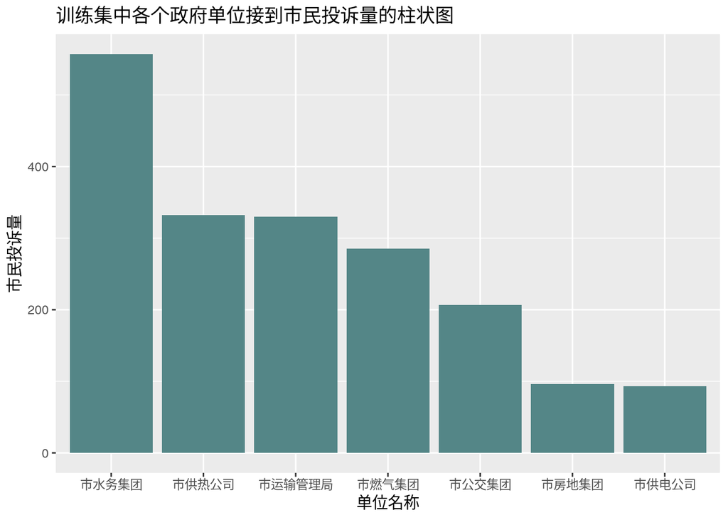

```r
ggplot(traindata, aes(x = reorder(单位名称, -rep(1, length(单位名称)), sum))) + geom_bar(fill = "#548687") +
  labs(x = '单位名称', y = '市民投诉量', title = '训练集中各个政府单位接到市民投诉量的柱状图')
```

观察到的现象：

1. 市水务集团接到的市民投诉量最多，在500条以上， 说明该市水务方面存在问题较多或对市民生活影响较大。
2. 市供电公司受到的市民投诉量最少，在100条以下， 说明该市供电方面问题较少或者对市民影响不大。

# 2 统计每条投诉用词数

统计每条投诉用词数并绘制分布直方图如下：

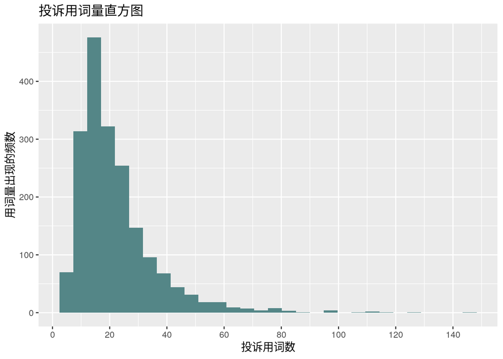

```r
traindata$wordcount <- rowSums(traindata[, 2:ncol(traindata)])
ggplot(traindata, aes(wordcount)) + geom_histogram(fill = '#548687') +
  labs(x = '投诉用词数', y = '用词量出现的频数', title = '投诉用词量直方图') +
  scale_x_continuous(breaks = seq(0, 150, 20))
```

观察到的现象：投诉量用词数集中在10~40词之间。

# 3 各单位收集到的次数差异

将各单位收集到投诉总词数对数的差异用箱线图展示如下：

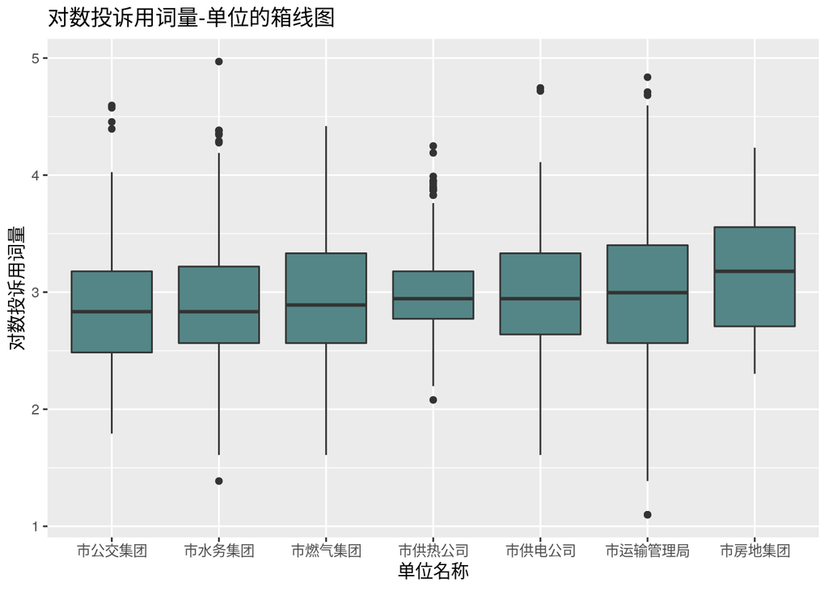

```r
ggplot(traindata, aes(x = reorder(单位名称, wordcount, median), y = log(wordcount))) +
  geom_boxplot(fill = "#548687") +
  labs(x = '单位名称', y = '对数投诉用词量', title = '对数投诉用词量-单位的箱线图')
```

箱线图说明：

1. 从用词量中位数来看：各个单位受到投诉用词量中位数相近， 市公交集团接受到投诉的用词量中位数最少， 市房地集团接受到投诉的用词量中位数最多。
2. 从用词量分布的密集程度来看，市供热公司接受到投诉用词量分布较集中， 其他单位受到投诉量分布密集程度相近。 说明在大多数情况下市民对供热的投诉的内容可能比较相近。
3. 从离群值来看，市供热公司接受到投诉量用词量离群值较多。 说明在一些情况下，市民对供热的投诉用词较多，可能是比较复杂的供热问题。

# 4 用朴素贝叶斯方法对市政电话文本进行建模

由于投诉建议文本整体长度较短，将每个词汇的被使用频数用是（1）-否（0）被使用替代：

```r
traindata.aug <- traindata
traindata.aug[,2:ncol(traindata.aug)] <- traindata[,2:ncol(traindata)] > 0
testdata.aug <- testdata
testdata.aug[,2:ncol(testdata.aug)] <- testdata[,2:ncol(testdata)] > 0
```

使用朴素贝叶斯模型对训练集数据进行建模：

```r
nbm <- naiveBayes(单位名称~., data = traindata.aug)
```

使用模型对测试集进行预测，并计算混淆矩阵：

```r
pred <- predict(nbm, testdata.aug[, 2:ncol(testdata.aug)])
confusion.matrix <- table(testdata.aug[,1], pred)
```

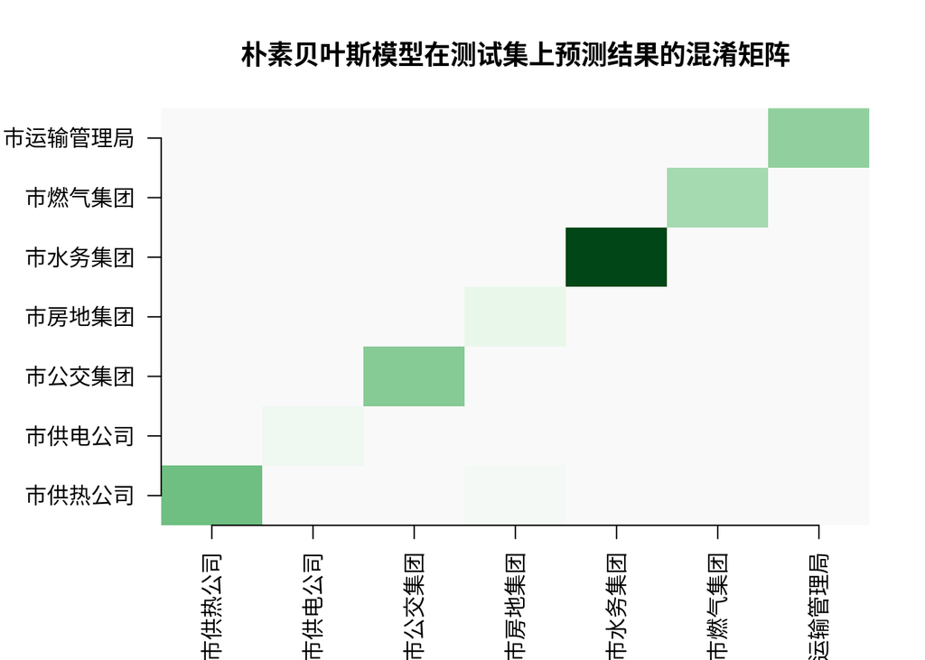

```r
par(mar=c(5.1, 6.1, 4.1, 2.1), las=2)
image(confusion.matrix, col = hcl.colors(n = 32, palette = "Greens 3", rev = T), axes = F)
axis(1, at = seq(0, 1, length = nrow(confusion.matrix)), labels = rownames(confusion.matrix))
axis(2, at = seq(0, 1, length = ncol(confusion.matrix)), labels = colnames(confusion.matrix))
title('朴素贝叶斯模型在测试集上预测结果的混淆矩阵')
```

模型在预测集上的准确率达到了97%， 从混淆矩阵可以看到 模型的预测效果较好。

需要注意的是， 测试集上各个单位受到的投诉量的相对大小与 训练集保持一致（比如，市水务集团最多，市供电公司最少）。 并且测试集数量较少（仅为训练集大小的$\frac{1}{19}$）， 因此想要进一步验证模型的泛化能力， 应该使用更多的测试数据， 并且考虑调整不同单位受到投诉量的比例。